# penplaqr vignette

Scott Coggeshall

August 6, 2018

This is a short vignette to demonstrate the main model-fitting function from penplaqr, the R package we are developing for fitting high-dimensional partially linear quantile regression models.

For this example, we simulated $n = 150$ observations on $p = 200$ covariates and a single outcome. The covariates were all simulated from independent $N(0, 1)$ distributions. Letting $x_i$ indicate the $i^{th}$ covariate, the outcome variable $y$ was then simulated as
$$\begin{equation}
y = \boldsymbol{\beta}^T\boldsymbol{x}_{1:195} + g(\boldsymbol{x}_{196:200}) + \epsilon
\end{equation}$$
where

- $\beta_1, \beta_2, \ldots, \beta_{150} = 0$
- $\beta_{151}, \beta_{152}, \ldots, \beta_{195} \overset{iid}{\sim} N(3, 1)$
- $g(\boldsymbol{x}_{196:200}) = sin(x_{196}) + log(x_{196}^2) + \ldots + sin(x_{200}) + log(x_{200}^2)$
- $\epsilon \sim N(0, 1)$

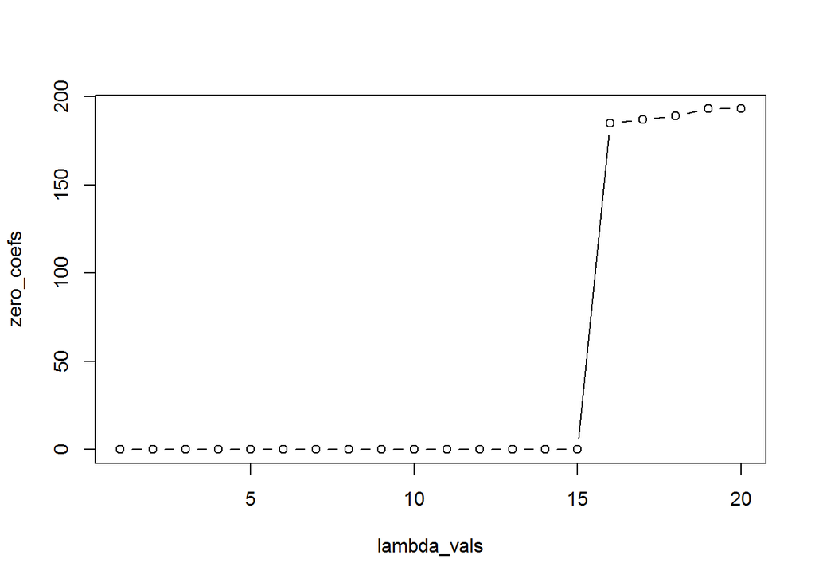

```r
# setting sample size and dimension of predictors
# note that p > n
p <- 200
n <- 150

# simulating covariate data from a multivariate normal distribution
set.seed(30)
X <- mvrnorm(n, mu = rep(0, p), Sigma = diag(1, nrow = p))

# simulating outcome data
# the first 150 covariates are unrelated to the outcome
# the next 45 covariates are linearly related to the outcome
# the final 5 covariates are related to the outcome through nonlinear functions

y <- X[,151:195]%*%rnorm(45, 3, sd = 1) + sin(X[,196:200])%*%rep(1, 5) + log(X[,196:200]^2)%*%rep(1, 5) + rnorm(n)

lambda_vals <- seq(from = 1, to = 20, by = 1)
my_dat <- as.data.frame(cbind(y, X))

names(my_dat) <- c("y", paste0("V", 1:200))

lin_formula <- as.formula(paste("y ~", paste0("V", 1:195, collapse = " + ")))
nonlin_formula <- as.formula(paste("~", paste0("V", 196:p, collapse = " + ")))
model_list <- vector(mode = "list", length = length(lambda_vals))
for(i in seq_along(lambda_vals)){
model_list[[i]] <- penplaqr(lin_formula, nonlinVars = nonlin_formula, data = my_dat, tau = .5, lambda = lambda_vals[i], a= 3.7,
                    penalty = "SCAD")

}

zero_coefs <- lapply(model_list, function(x) sum(coef(x) == 0))

plot(x = lambda_vals, y = zero_coefs, type = "b")
```

The next steps for this project are

- Implement the LASSO penalty
- Write code for performing tuning parameter selection
- Refine the main model fitting function (e.g. write code for handling missing data, clean up the function’s output, etc.)